# Project 1

## Dataset 4: Economics

```r
econ <- as.tibble(economics) %>%
  mutate(year = str_sub(date,1,4), unemploy_rate = (unemploy/pop)*100) %>%
  group_by(year) %>%
  mutate(er_sd = sd(unemploy_rate))
```

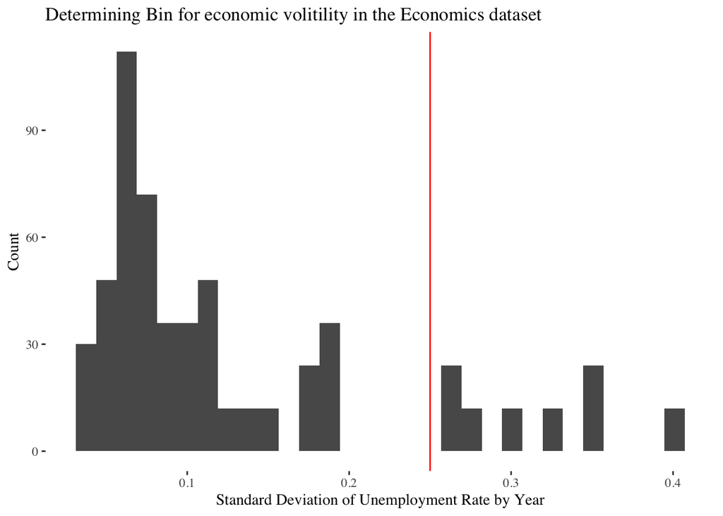

```r
hist <- ggplot(data = econ, mapping = aes(x = er_sd)) +
  geom_histogram() +
  geom_vline(xintercept = .25, colour = "red") +
  labs(title = "Determining Bin for economic volitility in the Economics dataset",
       x = "Standard Deviation of Unemployment Rate by Year",
       y = "Count") +
  ggthemes::theme_tufte()
hist
```

```r
volatility_characteristics <- econ %>%
  mutate(volatility_c2 = if_else(er_sd > .25, "High Volatility Year", "Average Volatility Year")) %>% group_by(volatility_c2) %>%
  mutate(n = length(unemploy_rate)) %>%
  group_by(volatility_c2) %>%
  summarise(`Average Unemployment Rate` = mean(unemploy_rate),
            `Average Personal Savings Rate` = mean(psavert),
            `Average Median Unemployment` = mean(uempmed)) %>%
  gather("volatility", "stat", `Average Unemployment Rate` , `Average Personal Savings Rate`, `Average Median Unemployment`) %>%
  dplyr::rename(statistic = volatility)
volatility_characteristics
```

| volatility_c2 | statistic | stat |
| --- | --- | --- |
| Average Volatility Year | Average Unemployment Rate | 2.912131 |
| High Volatility Year | Average Unemployment Rate | 3.370118 |
| Average Volatility Year | Average Personal Savings Rate | 7.714854 |
| High Volatility Year | Average Personal Savings Rate | 9.040625 |
| Average Volatility Year | Average Median Unemployment | 8.643305 |
| High Volatility Year | Average Median Unemployment | 8.444792 |

The visualization and summaries above are from the `econmics` dataset. These data are US economic monthly time series data made available by the St. Louis Federal Reserve. I was interested in exploring the relationship between savings rates and unemployment - both in rate and in duration. The visualziation represents a decision that I made in generating a variable built to characterize economic volatility in a given year. I computed the standard deviation in the unemployment rate for each year in the dataset, and then made a cutoff into high volatility or low volatitily year. Note that a high volatility year does not necessarily mean that a year expereienced a large decrease in the unemployment rate, it could be a large gain as well. The measure characterizes change in the economy via unemployment. This categorical variable was then used to compute summary statistics for each of unemployment rate, personal savings rate, and avverage median unemployment. Further analysis could be done by computing standard errors, and conducting statistical tests on the effect of volatility in the unemploymenr rate on each of these sample means.